# Remittances and Financial Preparedness for Old Age: Evidence from Household-Level Data

Author

Romaissae Kharrab

Published

February 8, 2026

## Introduction

```r
rm(list=ls()) #This line of code cleans the environment

# Load libraries (or packages):
library(tidyverse) #This library contains the most important functions you'll be using, download it everytime
library(patchwork)  # This library is very useful to combine multiple plots into one

#Load the dataset:
dataset = read_csv("findex_microdata_2025.csv")
```

Population ageing reinforces the importance of households’ financial preparedness for old age, particularly in countries where formal pension systems are limited, fragmented, or largely confined to the formal sector. In this context, remittances constitute a major and relatively stable source of income for many households, playing a central role in poverty reduction, the management of economic shocks, and income security. However, their impact on long-term financial behavior, especially saving for old age, remains ambiguous and insufficiently documented.

From a theoretical perspective, the receipt of remittances is likely to alter households’ intertemporal trade-offs. By acting as a form of informal insurance or anticipated income, these transfers may reduce incentives to accumulate savings explicitly intended for retirement. This substitution mechanism is further reinforced by institutional and social factors, such as limited pension coverage, low financial literacy, and norms of intergenerational solidarity, which encourage greater reliance on family networks rather than individual long-term financial planning.

This study therefore addresses the following research question: What is the effect of receiving remittances on households’ financial preparedness for old age?

H1: Households that receive remittances are less likely to save for old age than non-recipient households.

## Descriptive Sstatistics

### Key variables: Remittance Receipts and Saving for Old Age

```r
dataset <- dataset %>%
  mutate(
    # Construct a binary variable capturing remittance receipt in general.
    # The objective is to measure households’ overall exposure to remittances,
    # regardless of whether transfers are domestic or international,
    # and irrespective of the channel through which they are received.

    remittance_any = if_else(
      # The variable takes the value 1 if the household reports receiving
      # at least one type of remittance:
      # - fh2   : domestic remittance
      # - fin29 : digital domestic remittance
      # - fh2a  : international remittance
      fh2 == 1 | fin29 == 1 | fh2a == 1,

      # Value 1 indicates that the household is classified as a remittance recipient
      1,

      # Value 0 indicates that the household reports no remittance receipt
      0,

      # Missing values (e.g., "Don't know" or "Refused", previously recoded as NA)
      # are treated as non-receipt when no positive information is available
      missing = 0
    )
  )
```

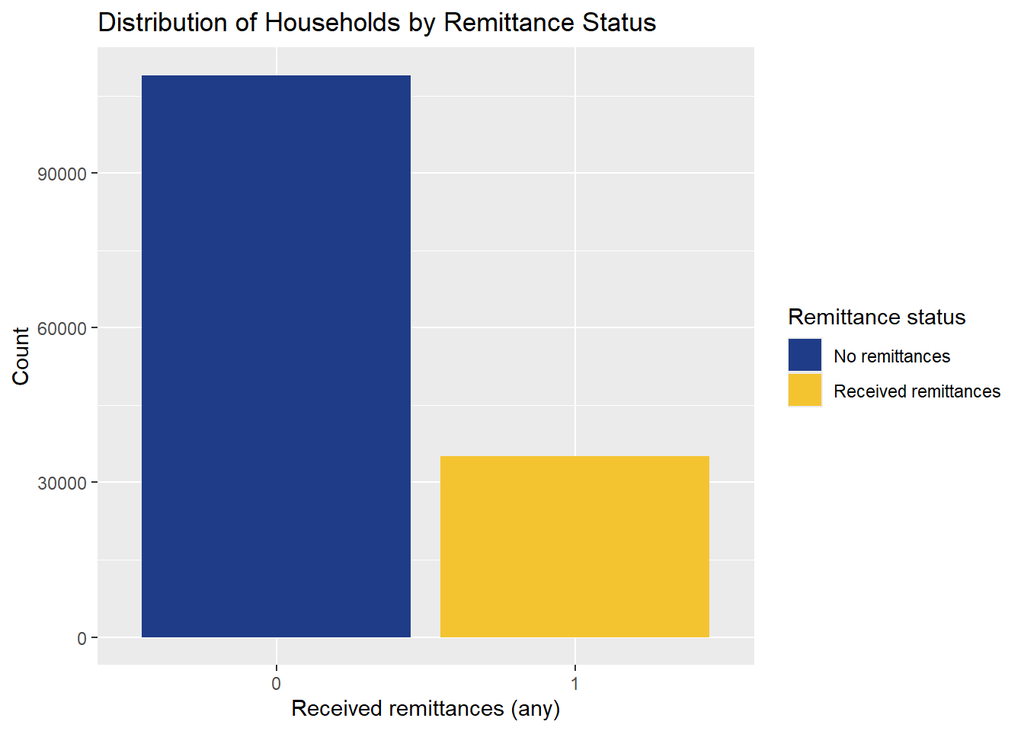

```r
library(ggplot2)

# Plot the distribution of households receiving remittances (any type)
# This bar chart displays the number of households that receive at least one
# type of remittance versus those that do not.

dataset %>%
  # Exclude observations with missing information on remittance receipt
  filter(!is.na(remittance_any)) %>%

  # Create a bar plot using the remittance indicator as a categorical variable
  ggplot(aes(x = factor(remittance_any), fill = factor(remittance_any))) +

  geom_bar() +

  scale_fill_manual(
    values = c("0" = "#1F3C88", "1" = "#F4C430"),
    labels = c("No remittances", "Received remittances")
  ) +

  labs(
    title = "Distribution of Households by Remittance Status",
    x = "Received remittances (any)",
    y = "Count",
    fill = "Remittance status"
  )
```

The distribution shows that most households do not receive remittances, although a non-negligible share reports receiving them.

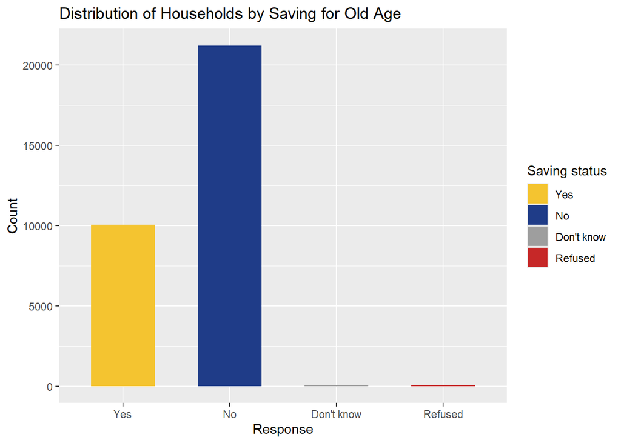

```r
dataset %>%
  filter(!is.na(fin17f)) %>%
  mutate(
    fin17f = recode(
      fin17f,
      `1` = "Yes",
      `2` = "No",
      `3` = "Don't know",
      `4` = "Refused"
    ),
    fin17f = factor(
      fin17f,
      levels = c("Yes", "No", "Don't know", "Refused")
    )
  ) %>%

ggplot(aes(x = fin17f, fill = fin17f)) +
  geom_bar(width = 0.6) +
  scale_fill_manual(
    values = c(
      "Yes" = "#F4C430",
      "No" = "#1F3C88",
      "Don't know" = "#9E9E9E",
      "Refused" = "#C62828"
    ),
    drop = FALSE
  ) +
  labs(
    title = "Distribution of Households by Saving for Old Age",
    x = "Response",
    y = "Count",
    fill = "Saving status"
  )
```

The figure shows that most households did not save for old age in the past 12 months, while a smaller but non-negligible share reported having saved. Overall, the distribution points to limited financial preparedness for old age, motivating further analysis of differences in saving behavior, particularly by remittance status.

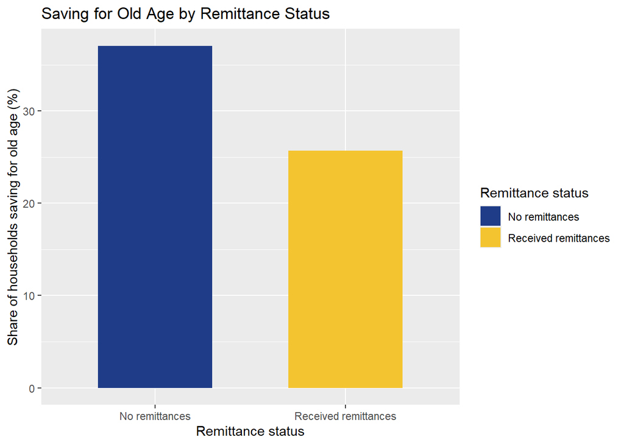

```r
library(dplyr)
library(ggplot2)

# This code compares saving for old age between households
# that receive remittances and those that do not.
# The figure is purely descriptive and does not imply causality.

dataset %>%

  # Keep only observations with valid information on
  # remittance receipt and saving for old age
  filter(!is.na(remittance_any), !is.na(fin17f)) %>%

  # Recode variables to improve readability and interpretation
  mutate(
    # Convert the remittance indicator into a labeled factor
    remittance_any = factor(
      remittance_any,
      levels = c(0, 1),
      labels = c("No remittances", "Received remittances")
    ),

    # Create a binary indicator for saving for old age
    # (1 = saved for old age, 0 = did not save)
    save_old_age = if_else(fin17f == 1, 1, 0)
  ) %>%

  # Compute the share of households saving for old age
  # separately for remittance recipients and non-recipients
  group_by(remittance_any) %>%
  summarise(
    share_saving_old_age = mean(save_old_age) * 100
  ) %>%

  # Plot the comparison across remittance status
  ggplot(aes(x = remittance_any,
             y = share_saving_old_age,
             fill = remittance_any)) +

  # Use a bar chart to display the shares
  geom_col(width = 0.6) +

  # Apply a consistent and visually appealing color palette
  scale_fill_manual(
    values = c(
      "No remittances" = "#1F3C88",      # deep blue
      "Received remittances" = "#F4C430" # soft gold
    )
  ) +

  # Add a descriptive title and axis labels
  labs(
    title = "Saving for Old Age by Remittance Status",
    x = "Remittance status",
    y = "Share of households saving for old age (%)",
    fill = "Remittance status"
  )
```

Among households that do not receive remittances, approximately 35–37% report having saved for old age in the past 12 months. By contrast, among remittance-receiving households, this proportion falls to around 25–27%.

### Control Variables and Descriptive Characteristics

To account for differences in households’ saving behavior, the analysis includes a set of control variables that reflect key demographic, socioeconomic, and contextual characteristics likely to influence both remittance receipt and financial preparedness for old age. Gender is taken into account through an indicator identifying whether the respondent is female, as men and women often differ in their labor market experiences, income stability, access to financial services, and roles in household financial decision-making. Education level is included as a proxy for human capital and financial literacy, since more educated individuals are generally better equipped to plan ahead, understand financial products, and engage in long-term saving.

The place of residence is also considered through a rural–urban indicator. Living in a rural area is often associated with more limited access to formal financial institutions and pension schemes, as well as a greater reliance on informal support networks, all of which can shape saving behavior and dependence on remittances.Household income is included to capture differences in households’ room to save, as higher income levels allow households to meet current needs more easily and leave greater scope for setting resources aside for the future. At the same time, income shapes how households perceive the role of remittances: for lower-income households, remittances may be essential for day-to-day consumption, whereas for better-off households they may be less central or more easily saved.

Finally, the analysis incorporates a measure of perceived financial vulnerability, captured by the variable identifying the respondent’s greatest financial worry. This variable reflects how financially constrained or insecure households feel, which can influence both their ability to save and their expectations regarding future support, including remittances. Together, these control variables help provide a clearer picture of the relationship between remittance receipt and saving for old age.

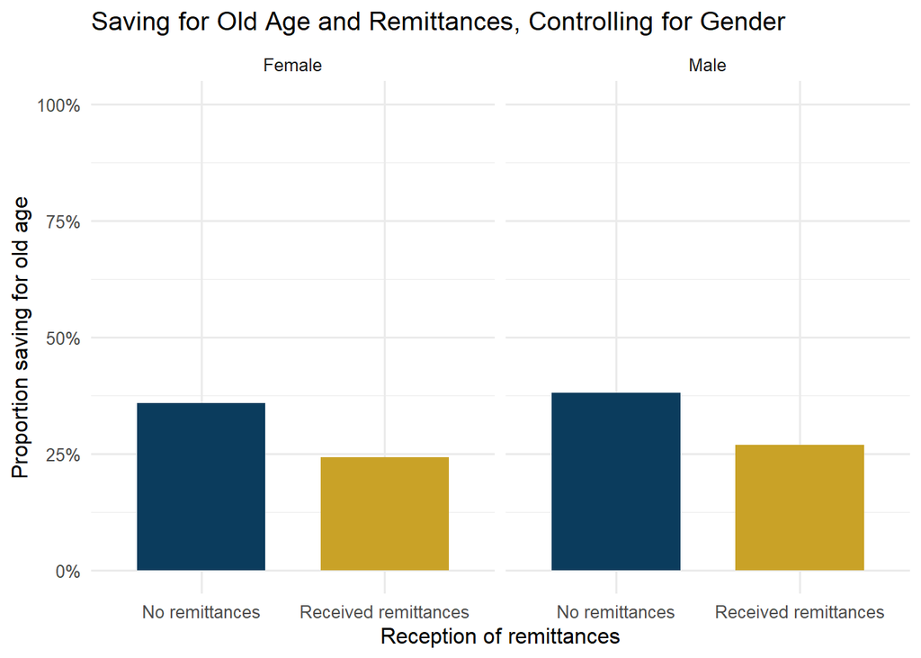

```r
library(dplyr)
library(ggplot2)
library(scales)

dataset %>%
  # Data cleaning
  # Exclude observations with missing values
  # in order to avoid biases in the computation of proportions
  filter(!is.na(remittance_any),
         !is.na(fin17f),
         !is.na(female)) %>%

  # Data grouping
  # - remittance_any: receipt of remittances (0 = no, 1 = yes)
  # - female: gender (1 = Female, 2 = Male)
  group_by(remittance_any, female) %>%

  # Computation of the proportion of individuals who saved for old age
  # fin17f is a binary variable:
  # fin17f == 1 → saved for old age
  summarise(
    prop_saved_old_age = mean(fin17f == 1),
    .groups = "drop"
  ) %>%

  # Plot construction
  ggplot(aes(
    x = factor(remittance_any,
               labels = c("No remittances", "Received remittances")),
    y = prop_saved_old_age,
    fill = factor(remittance_any)
  )) +

  # Bar chart
  # width controls spacing for better readability
  geom_col(width = 0.7) +

  # Gender control using facets
  facet_wrap(
    ~ female,
    labeller = as_labeller(c(
      `1` = "Female",
      `2` = "Male"
    ))
  ) +

  scale_fill_manual(
    values = c(
      "0" = "#0B3C5D",
      "1" = "#C9A227"
    ),
    guide = "none"     # Remove legend (redundant)
  ) +

  # Y-axis formatting
  # Percentage display
  scale_y_continuous(
    labels = percent_format(accuracy = 1),
    limits = c(0, 1)
  ) +

  labs(
    x = "Reception of remittances",
    y = "Proportion saving for old age",
    title = "Saving for Old Age and Remittances, Controlling for Gender"
  ) +

  theme_minimal(base_size = 12)
```

Conditional on gender, individuals who receive remittances are less likely to save for old age than those who do not receive remittances. This negative association holds for both women and men.

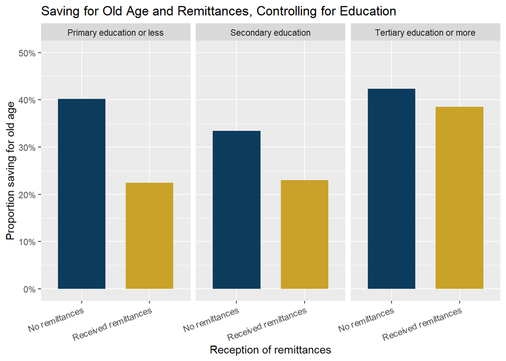

```r
library(dplyr)
library(ggplot2)
library(scales)

dataset %>%
  #  Data cleaning
  # Exclude observations with missing values to avoid distorted proportions
  filter(
    !is.na(remittance_any),
    !is.na(fin17f),
    !is.na(educ)
  ) %>%

  #  Grouping

  group_by(remittance_any, educ) %>%

  #  Compute the proportion of individuals who saved for old age
  summarise(
    prop_saved_old_age = mean(fin17f == 1),
    .groups = "drop"
  ) %>%

  # Build the plot
  ggplot(aes(
    x = factor(remittance_any,
               labels = c("No remittances", "Received remittances")),
    y = prop_saved_old_age,
    fill = factor(remittance_any)
  )) +

  #Bar chart
  geom_col(width = 0.7) +

  # Control for education level via facets
  # Replace numeric codes with explicit labels
  facet_wrap(
    ~ educ,
    labeller = as_labeller(c(
      `1` = "Primary education or less",
      `2` = "Secondary education",
      `3` = "Tertiary education or more"
    ))
  ) +

  scale_fill_manual(
    values = c(
      "0" = "#0B3C5D",
      "1" = "#C9A227"
    ),
    guide = "none"     # Remove legend (redundant)
  ) +

  #  Y-axis formatting
  # - Display as percentage
  # - Force limits between 0 and 100%
  scale_y_continuous(
    labels = percent_format(accuracy = 1),
    limits = c(0, 0.5)
  ) +

  labs(
    x = "Reception of remittances",
    y = "Proportion saving for old age",
    title = "Saving for Old Age and Remittances, Controlling for Education"
  ) +

  theme(
    axis.text.x = element_text(
      angle = 20,
      hjust = 1,
      vjust = 1
    )
)
```

Among individuals with low and medium education, receiving remittances is associated with a lower likelihood of saving for old age compared to those who do not receive remittances.

In contrast, among individuals with tertiary education or higher, the difference between remittance receivers and non-receivers is much smaller, with both groups displaying relatively high saving rates. This indicates that higher education mitigates the negative association between remittances and long-term saving, likely by enhancing financial planning capacity and intertemporal decision-making.

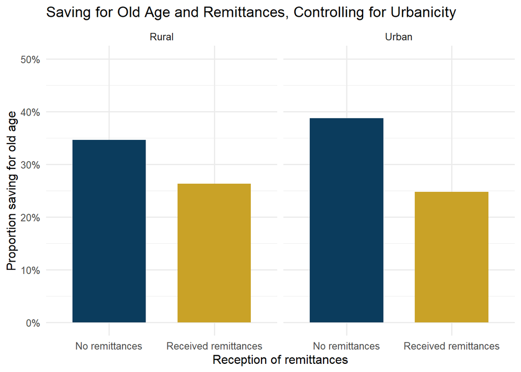

```r
library(dplyr)
library(ggplot2)
library(scales)

dataset %>%
  # Data cleaning
  # Exclude observations with missing values to avoid distorted proportions
  filter(
    !is.na(remittance_any),
    !is.na(fin17f),
    !is.na(urbanicity)
  ) %>%

  # Grouping
  # remittance_any: 0 = no, 1 = yes
  # urbanicity: 1 = Rural, 2 = Urban
  group_by(remittance_any, urbanicity) %>%

  # Compute the proportion of individuals who saved for old age
  summarise(
    prop_saved_old_age = mean(fin17f == 1),
    .groups = "drop"
  ) %>%

  # Build the plot
  ggplot(aes(
    x = factor(remittance_any,
               labels = c("No remittances", "Received remittances")),
    y = prop_saved_old_age,
    fill = factor(remittance_any)
  )) +

  # Bar chart
  geom_col(width = 0.7) +

  # Control for urban/rural via facets
  facet_wrap(
    ~ urbanicity,
    labeller = as_labeller(c(
      `1` = "Rural",
      `2` = "Urban"
    ))
  ) +


  scale_fill_manual(
    values = c(
      "0" = "#0B3C5D",
      "1" = "#C9A227"
    ),
    guide = "none"
  ) +

  # Y-axis formatting
  scale_y_continuous(
    labels = percent_format(accuracy = 1),
    limits = c(0, 0.5)
  ) +


  labs(
    x = "Reception of remittances",
    y = "Proportion saving for old age",
    title = "Saving for Old Age and Remittances, Controlling for Urbanicity"
  ) +


  theme_minimal(base_size = 12)
```

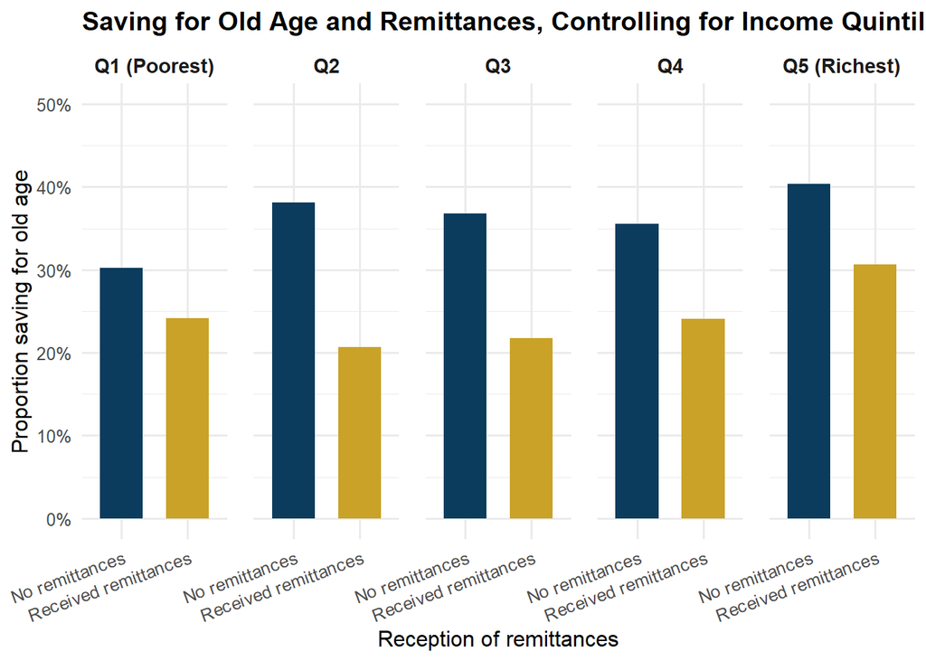

```r
library(dplyr)
library(ggplot2)
library(scales)

dataset %>%
  # Data cleaning
  # Exclude observations with missing values to avoid distorted proportions
  filter(
    !is.na(remittance_any),
    !is.na(fin17f),
    !is.na(inc_q)
  ) %>%

  # Grouping
  # remittance_any: 0 = no, 1 = yes
  # inc_q: household income quintile (1 = poorest, 5 = richest)
  group_by(remittance_any, inc_q) %>%

  # Compute the proportion of individuals who saved for old age
  summarise(
    prop_saved_old_age = mean(fin17f == 1),
    .groups = "drop"
  ) %>%

  # Build the plot
  ggplot(aes(
    x = factor(
      remittance_any,
      labels = c("No remittances", "Received remittances")
    ),
    y = prop_saved_old_age,
    fill = factor(remittance_any)
  )) +

  # Bar chart
  geom_col(width = 0.65) +

  # Control for income quintile via facets
  # Put all quintiles on one row (cleaner layout)
  facet_wrap(
    ~ inc_q,
    nrow = 1,
    labeller = as_labeller(c(
      `1` = "Q1 (Poorest)",
      `2` = "Q2",
      `3` = "Q3",
      `4` = "Q4",
      `5` = "Q5 (Richest)"
    ))
  ) +


  scale_fill_manual(
    values = c(
      "0" = "#0B3C5D",
      "1" = "#C9A227"
    ),
    guide = "none"
  ) +

  # Y-axis formatting
  scale_y_continuous(
    labels = percent_format(accuracy = 1),
    limits = c(0, 0.5)
  ) +


  labs(
    x = "Reception of remittances",
    y = "Proportion saving for old age",
    title = "Saving for Old Age and Remittances, Controlling for Income Quintiles"
  ) +


  theme_minimal(base_size = 12) +
  theme(
    # Make facet headers cleaner
    strip.text = element_text(size = 11, face = "bold"),
    panel.spacing = unit(1.0, "lines"),

    # Prevent x labels from cluttering the small panels
    axis.text.x = element_text(angle = 20, hjust = 1, vjust = 1),

    # Better title balance
    plot.title = element_text(face = "bold")
  )
```

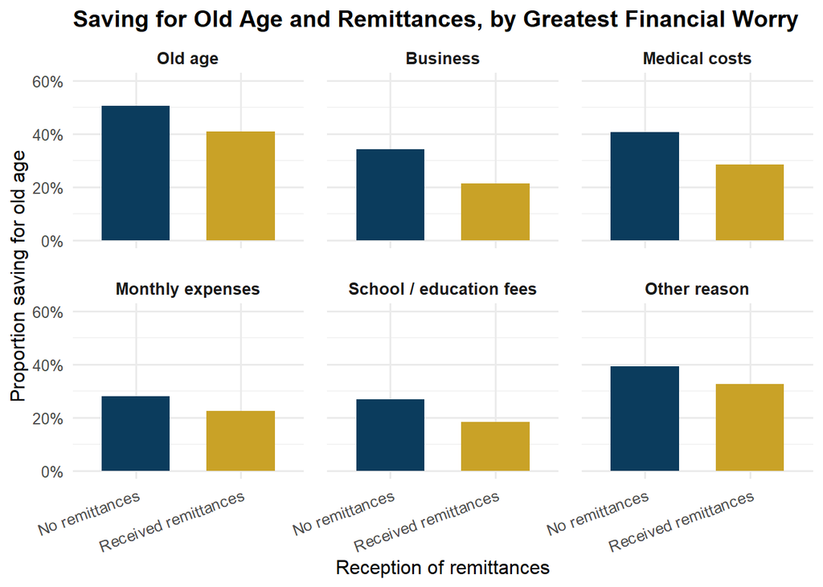

```r
library(dplyr)
library(ggplot2)
library(scales)

dataset %>%
  # Data cleaning
  # Exclude observations with missing values to avoid distorted proportions
  #fin45 includes non-informative response categories: 7 = "Don't know"; 8 = "Refused"
  # These categories do not represent a meaningful financial concern
  filter(
    !is.na(remittance_any),
    !is.na(fin17f),
    !is.na(fin45),
    fin45 %in% 1:6
  ) %>%


  # Grouping
  # remittance_any: 0 = no remittances, 1 = received remittances
  # fin45: greatest financial worry (categorical)
  group_by(remittance_any, fin45) %>%

  #  Compute the proportion of individuals who saved for old age
  # fin17f == 1 → saved for old age
  summarise(
    prop_saved_old_age = mean(fin17f == 1),
    .groups = "drop"
  ) %>%

  # Build the plot
  ggplot(aes(
    x = factor(
      remittance_any,
      labels = c("No remittances", "Received remittances")
    ),
    y = prop_saved_old_age,
    fill = factor(remittance_any)
  )) +

  # Bar chart
  geom_col(width = 0.65) +

  #  Control for greatest financial worry via facets
  facet_wrap(
    ~ fin45,
    nrow = 2,
    labeller = as_labeller(c(
      `1` = "Old age",
      `2` = "Business",
      `3` = "Medical costs",
      `4` = "Monthly expenses",
      `5` = "School / education fees",
      `6` = "Other reason"
    ))
  ) +

  scale_fill_manual(
    values = c(
      "0" = "#0B3C5D",
      "1" = "#C9A227"
    ),
    guide = "none"
  ) +

  # Y-axis formatting
  scale_y_continuous(
    labels = percent_format(accuracy = 1),
    limits = c(0, 0.6)
  ) +


  labs(
    x = "Reception of remittances",
    y = "Proportion saving for old age",
    title = "Saving for Old Age and Remittances, by Greatest Financial Worry"
  ) +


  theme_minimal(base_size = 12) +
  theme(
    strip.text = element_text(size = 10, face = "bold"),
    panel.spacing = unit(1, "lines"),
    axis.text.x = element_text(angle = 20, hjust = 1, vjust = 1),
    plot.title = element_text(face = "bold")
  )
```

Saving for old age varies clearly across types of financial worry, with higher saving rates among individuals worried about old age or medical costs and lower rates among those concerned with monthly expenses or education fees. Within each category, individuals who receive remittances consistently show slightly lower saving rates than those who do not. Overall, the pattern between remittance receipt and saving for old age is similar across all types of financial worry.

It is also particularly insightful to explore how the relationship between remittance receipt and saving for old age differs across world regions, as regional economic structures and financial environments may shape household saving behavior in distinct ways

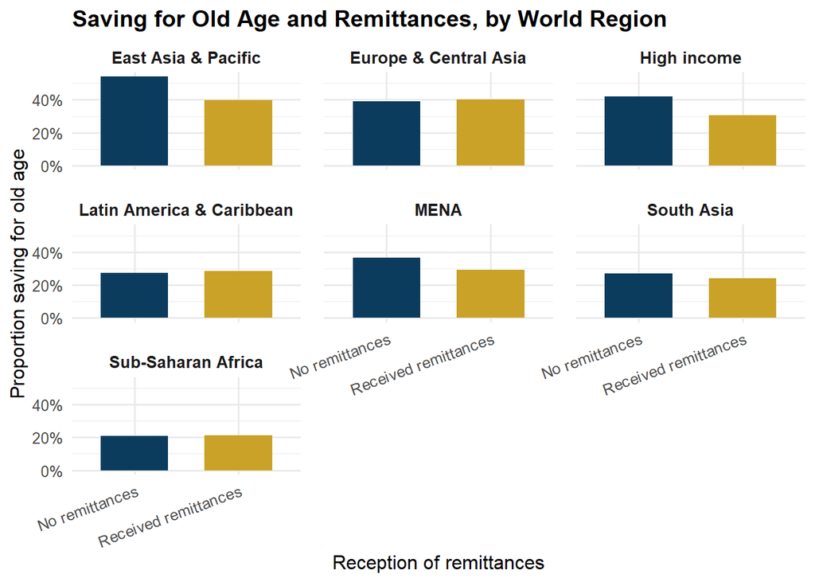

```r
library(dplyr)
library(ggplot2)
library(scales)

dataset %>%
  # Data cleaning
  # Exclude observations with missing values to avoid biased proportions
  # regionwb corresponds to the World Bank regional classification
  filter(
    !is.na(remittance_any),
    !is.na(fin17f),
    !is.na(regionwb)
  ) %>%

  # Grouping
  # remittance_any: 0 = no remittances, 1 = received remittances
  # regionwb
  group_by(regionwb, remittance_any) %>%

  # Compute the proportion of individuals who saved for old age
  # fin17f == 1 → saved for old age
  summarise(
    prop_saved_old_age = mean(fin17f == 1),
    .groups = "drop"
  ) %>%

  # Build the plot
  ggplot(aes(
    x = factor(
      remittance_any,
      labels = c("No remittances", "Received remittances")
    ),
    y = prop_saved_old_age,
    fill = factor(remittance_any)
  )) +

  # Bar chart
  geom_col(width = 0.65) +

  # Control for region via facets
  # Region labels are shortened for better readability
  facet_wrap(
    ~ regionwb,
    labeller = as_labeller(c(
      "East Asia & Pacific (excluding high income)" = "East Asia & Pacific",
      "Europe & Central Asia (excluding high income)" = "Europe & Central Asia",
      "Latin America & Caribbean (excluding high income)" = "Latin America & Caribbean",
      "Middle East & North Africa (excluding high income)" = "MENA",
      "Sub-Saharan Africa (excluding high income)" = "Sub-Saharan Africa",
      "South Asia" = "South Asia",
      "High income" = "High income"
    ))
  ) +

  scale_fill_manual(
    values = c(
      "0" = "#0B3C5D",
      "1" = "#C9A227"
    ),
    guide = "none"
  ) +

  # Y-axis formatting
  scale_y_continuous(
    labels = percent_format(accuracy = 1)
  ) +

  labs(
    x = "Reception of remittances",
    y = "Proportion saving for old age",
    title = "Saving for Old Age and Remittances, by World Region"
  ) +

  theme_minimal(base_size = 12) +
  theme(
    strip.text = element_text(size = 10, face = "bold"),
    panel.spacing = unit(1, "lines"),
    axis.text.x = element_text(angle = 20, hjust = 1, vjust = 1),
    plot.title = element_text(face = "bold")
  )
```

Individuals receiving remittances do not exhibit a uniform saving pattern across regions. In several regions, including East Asia & Pacific, High-income economies, and MENA, remittance recipients show slightly lower saving rates for old age than non-recipients, suggesting that remittances may partly substitute for formal long-term savings. In Sub-Saharan Africa and Latin America & the Caribbean, saving rates are broadly similar between recipients and non-recipients, indicating a weak association. By contrast, in Europe & Central Asia, individuals receiving remittances display marginally higher saving rates, suggesting that remittance income may in some contexts ease liquidity constraints and support additional saving. Overall, the descriptive evidence reveals substantial regional heterogeneity in the relationship between remittance income and retirement saving behavior.

## Statistical Inference

To go beyond descriptive analysis, this section uses regression models to formally test whether receiving remittances is associated with saving for old age. Regression analysis allows us to estimate the magnitude of the relationship and assess its statistical significance while controlling for individual characteristics such as gender, age, education, income, and region. By comparing progressively richer model specifications, we examine whether the relationship remains once these factors are taken into account and whether the effect differs across regional contexts.

### Model 1 : Baseline model

We begin with a baseline specification that estimates the simple association between remittance receipt and the probability of saving for old age

```r
# Convert categorical variables into factors
# This ensures that R automatically creates dummy variables
# when these variables are included in regression models

dataset$regionwb   <- factor(dataset$regionwb)
dataset$female     <- factor(dataset$female)
dataset$educ       <- factor(dataset$educ)
dataset$inc_q      <- factor(dataset$inc_q)
dataset$fin45      <- factor(dataset$fin45)
dataset$urbanicity <- factor(dataset$urbanicity)


# Baseline Linear Probability Model (LPM)
# Dependent variable:
#   fin17f = 1 if the individual saved for old age
# Independent variable:
#   remittance_any = 1 if the individual received remittances
# This specification estimates the unconditional association
# between remittance receipt and saving for old age
model1 <- lm(
  fin17f ~ remittance_any,
  data = dataset
)

# Display regression results
summary(model1)
```

```
Call:
lm(formula = fin17f ~ remittance_any, data = dataset)

Residuals:
    Min      1Q  Median      3Q     Max
-0.7461 -0.6386  0.2539  0.3614  2.3614

Coefficients:
               Estimate Std. Error t value Pr(>|t|)
(Intercept)    1.638569   0.003621  452.51   <2e-16 ***
remittance_any 0.107522   0.005436   19.78   <2e-16 ***
---
Signif. codes:  0 '***' 0.001 '**' 0.01 '*' 0.05 '.' 0.1 ' ' 1

Residual standard error: 0.4787 on 31415 degrees of freedom
  (112673 observations effacées parce que manquantes)
Multiple R-squared:  0.0123,    Adjusted R-squared:  0.01227
F-statistic: 391.3 on 1 and 31415 DF,  p-value: < 2.2e-16
```

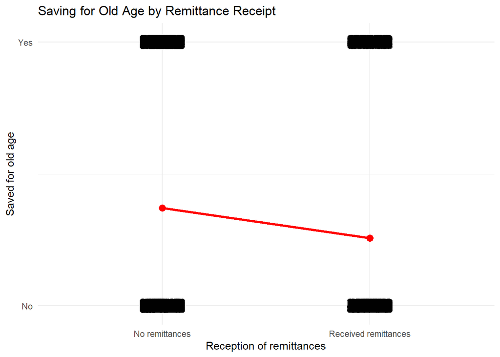

```r
library(dplyr)
library(ggplot2)

dataset <- dataset %>%
  mutate(save_old_age = ifelse(fin17f == 1, 1, 0))

ggplot(dataset, aes(
  x = factor(remittance_any,
             labels = c("No remittances", "Received remittances")),
  y = save_old_age
)) +

  # Individual observations
  geom_jitter(width = 0.1, height = 0.02, alpha = 0.3) +

  #difference in means
  stat_summary(
    fun = mean,
    geom = "line",
    aes(group = 1),
    color = "red",
    linewidth = 1.2
  ) +

  stat_summary(
    fun = mean,
    geom = "point",
    color = "red",
    size = 3
  ) +

  scale_y_continuous(
    breaks = c(0,1),
    labels = c("No", "Yes")
  ) +

  labs(
    x = "Reception of remittances",
    y = "Saved for old age",
    title = "Saving for Old Age by Remittance Receipt"
  ) +

  theme_minimal()
```

### Model 2 : Controlled specification

```r
# Convert the region variable into a categorical variable (factor) so that R creates dummy variables automatically in the regression
dataset$regionwb <- factor(dataset$regionwb)
# Replace long region names with shorter labels to make regression tables easier to read
levels(dataset$regionwb) <- c(
  "EAP",
  "ECA",
  "High income",
  "LAC",
  "MENA",
  "South Asia",
  "SSA"
)

# This model estimates the association between receiving remittances and saving for old age after controlling for individual characteristics and regional differences

model2 <- lm(
  fin17f ~ remittance_any + female + age + educ + inc_q + regionwb + urbanicity + fin45,
  data = dataset
)
summary(model2)
```

```
Call:
lm(formula = fin17f ~ remittance_any + female + age + educ +
    inc_q + regionwb + urbanicity + fin45, data = dataset)

Residuals:
    Min      1Q  Median      3Q     Max
-1.0042 -0.4602  0.1671  0.3075  2.6631

Coefficients:
                      Estimate Std. Error t value Pr(>|t|)
(Intercept)          1.7496805  0.0160258 109.179  < 2e-16 ***
remittance_any      -0.0007487  0.0058430  -0.128 0.898037
female2             -0.0271460  0.0052355  -5.185 2.17e-07 ***
age                 -0.0067524  0.0001885 -35.818  < 2e-16 ***
educ2               -0.0164095  0.0070408  -2.331 0.019780 *
educ3               -0.0759197  0.0087333  -8.693  < 2e-16 ***
inc_q2              -0.0254948  0.0109176  -2.335 0.019540 *
inc_q3              -0.0180473  0.0103983  -1.736 0.082646 .
inc_q4              -0.0265588  0.0100375  -2.646 0.008150 **
inc_q5              -0.0730496  0.0096501  -7.570 3.84e-14 ***
regionwbECA          0.1908999  0.0099180  19.248  < 2e-16 ***
regionwbHigh income  0.1499870  0.0117953  12.716  < 2e-16 ***
regionwbLAC          0.2238533  0.0100015  22.382  < 2e-16 ***
regionwbMENA         0.1695241  0.0131823  12.860  < 2e-16 ***
regionwbSouth Asia   0.2187229  0.0130874  16.713  < 2e-16 ***
regionwbSSA          0.2404748  0.0081909  29.359  < 2e-16 ***
urbanicity2          0.0090009  0.0053756   1.674 0.094066 .
fin452               0.0943856  0.0106868   8.832  < 2e-16 ***
fin453               0.0805714  0.0085606   9.412  < 2e-16 ***
fin454               0.1265432  0.0087549  14.454  < 2e-16 ***
fin455               0.1177086  0.0104150  11.302  < 2e-16 ***
fin456               0.0767461  0.0151514   5.065 4.10e-07 ***
fin457               0.1092442  0.0180158   6.064 1.35e-09 ***
fin458               0.1168274  0.0305152   3.828 0.000129 ***
---
Signif. codes:  0 '***' 0.001 '**' 0.01 '*' 0.05 '.' 0.1 ' ' 1

Residual standard error: 0.4532 on 30561 degrees of freedom
  (113505 observations effacées parce que manquantes)
Multiple R-squared:  0.114, Adjusted R-squared:  0.1134
F-statistic:   171 on 23 and 30561 DF,  p-value: < 2.2e-16
```

Once demographic, socioeconomic, and regional controls are included, the coefficient associated with remittance receipt is not statistically different from zero (p = 0.898), implying that we fail to reject the null hypothesis of no effect. In contrast, several control variables emerge as statistically significant predictors of saving for old age. Gender (p < 0.001) and age (p < 0.001) are both strongly significant, while education levels also display significant differences (educ2: p = 0.0198; educ3: p < 0.001). Income categories are mostly significant (inc_q2: p = 0.0195; inc_q4: p = 0.0082; inc_q5: p < 0.001), although inc_q3 is only weakly significant (p = 0.0826). All regional indicators are highly significant (p < 0.001), suggesting substantial regional heterogeneity in saving behavior. Urbanicity shows only marginal significance (p = 0.094), whereas the financial concern indicators (fin45 categories) are consistently significant at conventional levels (most p-values < 0.001). Finally, the overall model is jointly significant according to the F-test (p < 0.001), indicating that the explanatory variables collectively provide meaningful information about saving behavior.

### Model 3 : Regional interaction specification

To examine whether the effect of remittance receipt on saving for old age varies across different regional contexts, the analysis introduces interaction terms between remittance receipt and world regions in order to capture potential heterogeneity in the relationship.

```r
# This model examines whether the effect of receiving remittances on saving for old age differs across regions.
model3 <- lm(
  fin17f ~ remittance_any*regionwb + female + age + educ + inc_q + urbanicity + fin45,
  data = dataset
)

summary(model3)
```

```
Call:
lm(formula = fin17f ~ remittance_any * regionwb + female + age +
    educ + inc_q + urbanicity + fin45, data = dataset)

Residuals:
    Min      1Q  Median      3Q     Max
-1.0157 -0.4540  0.1665  0.3058  2.6627

Coefficients:
                                     Estimate Std. Error t value Pr(>|t|)
(Intercept)                         1.7308064  0.0162863 106.274  < 2e-16 ***
remittance_any                      0.1020601  0.0162825   6.268 3.70e-10 ***
regionwbECA                         0.2274933  0.0114939  19.793  < 2e-16 ***
regionwbHigh income                 0.1591983  0.0127879  12.449  < 2e-16 ***
regionwbLAC                         0.2607473  0.0123860  21.052  < 2e-16 ***
regionwbMENA                        0.1723106  0.0146756  11.741  < 2e-16 ***
regionwbSouth Asia                  0.2322581  0.0160309  14.488  < 2e-16 ***
regionwbSSA                         0.2693284  0.0101811  26.454  < 2e-16 ***
female2                            -0.0265551  0.0052323  -5.075 3.89e-07 ***
age                                -0.0067270  0.0001884 -35.697  < 2e-16 ***
educ2                              -0.0171987  0.0070362  -2.444 0.014519 *
educ3                              -0.0759532  0.0087263  -8.704  < 2e-16 ***
inc_q2                             -0.0247317  0.0109066  -2.268 0.023361 *
inc_q3                             -0.0178420  0.0103885  -1.717 0.085901 .
inc_q4                             -0.0282026  0.0100291  -2.812 0.004925 **
inc_q5                             -0.0758211  0.0096458  -7.861 3.95e-15 ***
urbanicity2                         0.0108268  0.0053801   2.012 0.044190 *
fin452                              0.0946182  0.0106789   8.860  < 2e-16 ***
fin453                              0.0803698  0.0085550   9.394  < 2e-16 ***
fin454                              0.1258425  0.0087490  14.384  < 2e-16 ***
fin455                              0.1165868  0.0104046  11.205  < 2e-16 ***
fin456                              0.0788952  0.0151401   5.211 1.89e-07 ***
fin457                              0.1077334  0.0180000   5.985 2.19e-09 ***
fin458                              0.1141393  0.0304836   3.744 0.000181 ***
remittance_any:regionwbECA         -0.1582234  0.0225309  -7.023 2.22e-12 ***
remittance_any:regionwbHigh income -0.0381604  0.0322386  -1.184 0.236546
remittance_any:regionwbLAC         -0.1427010  0.0222273  -6.420 1.38e-10 ***
remittance_any:regionwbMENA        -0.0258084  0.0329825  -0.782 0.433934
remittance_any:regionwbSouth Asia  -0.0881840  0.0283818  -3.107 0.001891 **
remittance_any:regionwbSSA         -0.1169972  0.0184516  -6.341 2.32e-10 ***
---
Signif. codes:  0 '***' 0.001 '**' 0.01 '*' 0.05 '.' 0.1 ' ' 1

Residual standard error: 0.4527 on 30555 degrees of freedom
  (113505 observations effacées parce que manquantes)
Multiple R-squared:  0.1162,    Adjusted R-squared:  0.1154
F-statistic: 138.5 on 29 and 30555 DF,  p-value: < 2.2e-16
```

Model 3 represents the preferred specification, as it accounts for observable individual characteristics and allows the effect of remittances to vary across regions, thereby capturing potential heterogeneity in the relationship.